# Use letters for affiliations

## References

Corvetti, C. (2020). SaratogaHouses: Houses in Saratoga County (2006). mosaicData: Project MOSAIC Data Sets. https://rdrr.io/cran/mosaicData/man/SaratogaHouses.html

Kuhn, M. (2020). caret: Classification and Regression Training. R package version 6.0-86. https://CRAN.R-project.org/package=caret

Tarr G, Müller S, Welsh AH (2018). “mplot: An R Package for Graphical Model Stability and Variable Selection Procedures.” *Journal of Statistical Software*, *83*(9), 1-28. doi: 10.18637/jss.v083.i09 (URL: https://doi.org/10.18637/jss.v083.i09).

Wickham et al., (2019). Welcome to the tidyverse. Journal of Open Source Software, 4(43), 1686, https://doi.org/10.21105/joss.01686

## Appendix

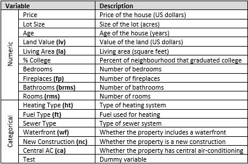

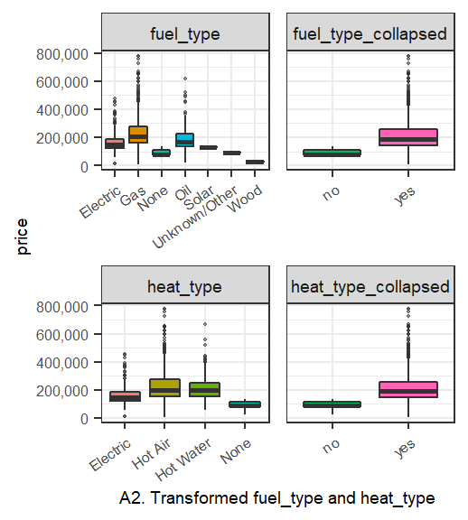

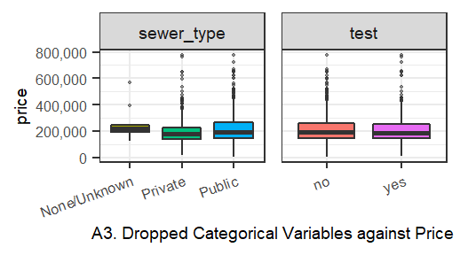

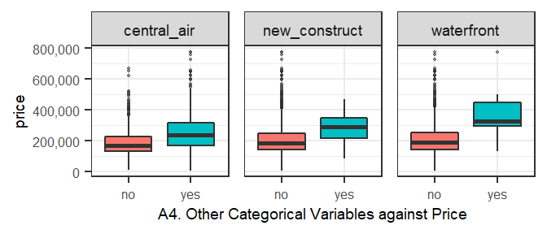

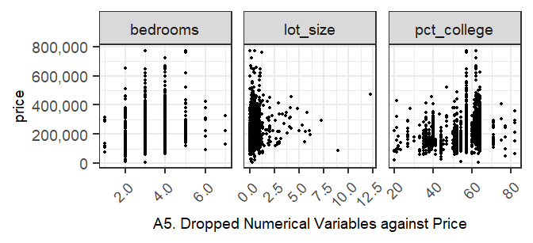

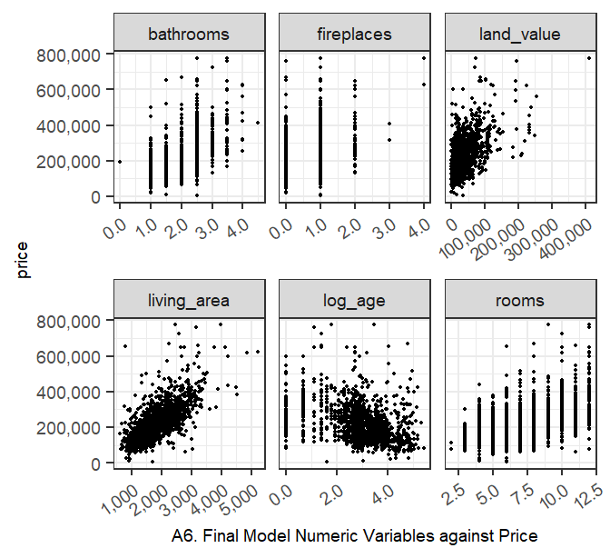

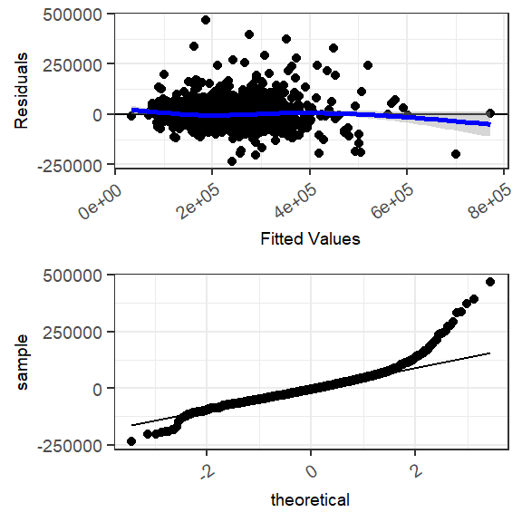